# UPHL.LIMS Cleanup [02]

T.Hooker

18 June, 2019

**Project Root Path** :: "U:_Cleanup_Scripts\190610_UPHL_LIMS_wy19q1q2_CLEANUP"

```r
#options(table_counter=FALSE)
tidy_package <- c("plyr", "dplyr", "tidyr", "magrittr", "htmlTable")
# suppressPackageStartupMessages(library("tidy"))
if(!"tidyr" %in% (.packages())) {invisible(lapply(tidy_package, function(x) suppressMessages(library(x, character.only=T, quietly = T, warn.conflicts = F))))}
##
# graph_package <- c("ggplot2", "scales")
# if(!"ggplot2" %in% (.packages())) {invisible(lapply(graph_package, library, character.only=T, quietly = T, warn.conflicts = F))}
##
options(scipen = 999, digits = 4, stringsAsFactors = FALSE, keep.source = TRUE)
##
#startwork.date <- format(Sys.Date(), "%y%m%d")
knitr::opts_chunk$set(cache=TRUE)
```

## 0.0 Notes

**[190610]**

**[190618]**

4. Notebook continues previous cleanup tasks, starting with project-level (as Project_GRP) review and modify (metadata) elements
5. Goal here is to ID record that *may match* to RP’s field_data, but have errors in one or more of the Sample-Key-Elements (Trip & MLID & SDate & SampType)
6. Once this is set (or complete), records can be re-compared against AWQMS data for the time-block and a decision made regard updating the chem-import
7. Chem - Parameter x Method cleanup can also occur once a reasonable set of projects are sufficiently commplete to allow import to awqms.

*Prior DFs and working sets*

EDD_0 :: master EDD file :: “EDD_0_190610.rds” :: “U:/INFODATA/Sampling/UPHL_raw_EDDs/uphl_EDD_rawProcessing_r”

EDD1_0 :: 2019 wy q1q2 file :: “edd1_wy19q1q2_RAW_190612.RDS” in Project-Folder

MonLoc :: Monitoring Locations from AWQMS :: “MonitoringLocationsIDs_051719.xlsx” “U:/INFODATA/Sampling/DWQ Monitoring Locations/Monitoring Location IDs” Last Accessed :: “2019-06-12 09:01:26 MDT”

EDD1_1 :: 2019.q1q2 w/ MLID-info joined :: “edd1_1_wy19q1q2_01_190613.RDS” + After awqms_ACTID join :: “edd1_1_wy19q1q2_02_190613.RDS”

awqms_ACTID_19q1q2 :: Activity.IDs from AWQMS for 19.q1q2 :: “awqms_ACTID_19q1q2_xx_190618.rds”

proj_MLID :: BBs file of MLID & Project sets for this coming year :: See:: “MonitoringSection2019_MLIDlist.xlsx” “U:/PERMITS/MONITORS/2019_wy_Data/2019_wy_Data Management/List of MLIDs” Last Accessed :: “2019-06-14 14:47:43 MDT”

field_0 :: RPs *raw field/hydrodata file* :: “3. 2019_WY_Q1_Q2_ALL_Field_Flow_prep_Combined.xlsx” “U:/PERMITS/MONITORS/2019_wy_Data/2019_wy_Hydrodata/2019_wy_4. Data and Information Services/WY_2019 Import prep/Q1 and Q2 (10-1-2018 through 3-31-2019)/Hydrodata” “2019-06-14 08:35:48 MDT”

field_1 :: RPs cleaned(tdh) hydrofile :: “field_1_xx_190618.rds”

EDD1_3 :: Working datafile at end of 1st notebook :: “EDD1_3_xx_190618.rds”

project_table2 :: sumamry table of `projects` (trimmed TripIDs) and `Project_GRP` for streamlined data-cleanup tasks :: “ProjectTable2_wy19q1q2_190618.rds”

```r
# some workspace cleanup...
```

**[190621]**

- Fixing some process errors in EDD data-cleanup and matchups

## 7.0 Project-Group Metadata Clean Up

```r
# project_table2 %<>% arrange(., Project_GRP, project)
```

Project data-groups to work through and clean up w/r to ::

1. Field data matchup
2. Parameter x Method combinations (and results data) review
3. check against ACTIDs already in AWQMS
4. prepare for import to awqms (RP)
- Project Groups Table
  - [190619]: changed HAB and USGS to “Unknown” project.grp

```r
# project_table2 %<>% mutate_if(is.factor, as.character) %>% mutate(
#   Project_GRP = case_when(
#     project == "HAB" ~ "Unknown",
#     project == "USGSGKM" ~ "Unknown",
#     !is.na(Project_GRP) ~ Project_GRP,
#     is.na(Project_GRP) ~ as.character(NA)),
#   project = case_when(
#     is.na(project) ~ "missing",
#     !is.na(project) ~ project)) %>%
#   arrange(Project_GRP, project)
```

- Add col for unique SK4s that match field data…

```r
F_proj <- project_table2$project[project_table2$NA_y > 0 & project_table2$project != "Sum"]
#
for (j in F_proj) {
  project_table2$k_fldSK4[project_table2$project == j] = length(unique(
    EDD1_3$SKey4[is.na(EDD1_3$field_sk4) &
                   !is.na(EDD1_3$project) & EDD1_3$project == j]))
}
#
project_table2 %<>% select(project:Sum, k_fldSK4, everything())
```

```r
project_table2 %>%
  htmlTable::htmlTable(., css.cell = rbind(rep("padding-left: 0.8em; padding-right: 0.8em;font-size: 0.75em;", times=ncol(.)+1), matrix("padding-left: 0.75em; padding-right: 0.75em; font-size: 0.75em;", ncol=ncol(.)+1, nrow=nrow(.))), total=T, align="rl|cc|ccc|c|c|l", caption="Project groups by [Import Stats x SKey4 field-match]")
```

| Project groups by [Import Stats x SKey4 field-match] | Project groups by [Import Stats x SKey4 field-match] project | Project groups by [Import Stats x SKey4 field-match] NA_NA | Project groups by [Import Stats x SKey4 field-match] NA_y | Project groups by [Import Stats x SKey4 field-match] yes_0_NA | Project groups by [Import Stats x SKey4 field-match] yes_1_NA | Project groups by [Import Stats x SKey4 field-match] yes_x_NA | Project groups by [Import Stats x SKey4 field-match] Sum | Project groups by [Import Stats x SKey4 field-match] k_fldSK4 | Project groups by [Import Stats x SKey4 field-match] Project_GRP |
| --- | --- | --- | --- | --- | --- | --- | --- | --- | --- |
| 1 | BLMGSE | 29 | 80 | 0 | 0 | 0 | 109 | 1 | COOP |
| 2 | BLMMOAB | 26 | 80 | 0 | 0 | 0 | 106 | 1 | COOP |
| 3 | BLMVERNAL | 156 | 180 | 0 | 0 | 0 | 336 | 10 | COOP |
| 4 | BLMVFOPFO | 0 | 224 | 0 | 0 | 0 | 224 | 0 | COOP |
| 5 | BORLP | 682 | 0 | 0 | 0 | 0 | 682 |  | COOP |
| 6 | DC | 174 | 1867 | 0 | 0 | 0 | 2041 | 6 | COOP |
| 7 | NFSASHELY | 0 | 27 | 0 | 0 | 0 | 27 | 0 | COOP |
| 8 | NFSASHLEY | 0 | 212 | 0 | 0 | 0 | 212 | 0 | COOP |
| 9 | NFSDIXIE | 63 | 252 | 0 | 0 | 0 | 315 | 3 | COOP |
| 10 | NPSCAN | 0 | 356 | 0 | 0 | 0 | 356 | 0 | COOP |
| 11 | NPSCANR | 78 | 312 | 0 | 0 | 0 | 390 | 2 | COOP |
| 12 | NPSETAL | 62 | 958 | 0 | 0 | 0 | 1020 | 2 | COOP |
| 13 | NPSETALTIMP | 39 | 61 | 0 | 0 | 0 | 100 | 1 | COOP |
| 14 | SLCO | 25 | 161 | 0 | 0 | 0 | 186 | 2 | COOP |
| 15 | CBI | 1595 | 13726 | 0 | 0 | 0 | 15321 | 45 | Intensive |
| 16 | LAKES | 56 | 296 | 186 | 0 | 0 | 538 | 10 | Lakes |
| 17 | LOGANRV | 63 | 225 | 0 | 0 | 0 | 288 | 7 | TMDL/NonPoint |
| 18 | MAINCK | 25 | 159 | 0 | 0 | 0 | 184 | 2 | TMDL/NonPoint |
| 19 | PELICANNPS | 3 | 24 | 0 | 0 | 0 | 27 | 1 | TMDL/NonPoint |
| 20 | SANPITCHNPS | 30 | 224 | 0 | 0 | 0 | 254 | 3 | TMDL/NonPoint |
| 21 | SCSCTMDL | 16 | 163 | 0 | 0 | 0 | 179 | 4 | TMDL/NonPoint |
| 22 | SNAKECKTMDL | 1 | 0 | 0 | 0 | 0 | 1 |  | TMDL/NonPoint |
| 23 | UPRSEVIERNPS | 169 | 0 | 0 | 0 | 0 | 169 |  | TMDL/NonPoint |
| 24 | UCASE | 0 | 0 | 0 | 0 | 293 | 293 |  | UCASE |
| 25 | HAB | 153 | 0 | 0 | 0 | 0 | 153 |  | Unknown |
| 26 | missing | 190 | 0 | 0 | 0 | 0 | 190 |  | Unknown |
| 27 | USGSGKM | 560 | 0 | 0 | 0 | 0 | 560 |  | Unknown |
| 28 | UTLK | 145 | 940 | 728 | 814 | 1203 | 3830 | 95 | Utah Lake |
| 29 | Sum | 4340 | 20527 | 914 | 814 | 1496 | 28091 |  |  |

- Aggregate Project-level completeness by `Project_GRP`

```r
project_table2 %>% slice(., 1:nrow(.)-1) %>%
  group_by(Project_GRP) %>%
  summarize_at(c("NA_NA","NA_y","yes_0_NA","yes_1_NA","yes_x_NA","Sum","k_fldSK4"),
               sum, na.rm=T) %>%
  add_row(.,
          Project_GRP = "Totals",
          NA_NA = sum(.$NA_NA, na.rm=T),
          NA_y = sum(.$NA_y, na.rm=T),
          yes_0_NA = sum(.$yes_0_NA, na.rm=T),
          yes_1_NA = sum(.$yes_1_NA, na.rm=T),
          yes_x_NA = sum(.$yes_x_NA, na.rm=T),
          Sum = sum(.$Sum, na.rm=T),
          k_fldSK4 = sum(.$k_fldSK4, na.rm=T)) %>%
  htmlTable::htmlTable(., css.cell = rbind(rep("padding-left: 0.8em; padding-right: 0.8em;font-size: 0.75em;", times=ncol(.)+1), matrix("padding-left: 0.75em; padding-right: 0.75em; font-size: 0.75em;", ncol=ncol(.)+1, nrow=nrow(.))), total=T, align="rl|cc|ccc|c|c", caption="Project group matchup Summary")
```

| Project group matchup Summary | Project group matchup Summary Project_GRP | Project group matchup Summary NA_NA | Project group matchup Summary NA_y | Project group matchup Summary yes_0_NA | Project group matchup Summary yes_1_NA | Project group matchup Summary yes_x_NA | Project group matchup Summary Sum | Project group matchup Summary k_fldSK4 |
| --- | --- | --- | --- | --- | --- | --- | --- | --- |
| 1 | COOP | 1334 | 4770 | 0 | 0 | 0 | 6104 | 28 |
| 2 | Intensive | 1595 | 13726 | 0 | 0 | 0 | 15321 | 45 |
| 3 | Lakes | 56 | 296 | 186 | 0 | 0 | 538 | 10 |
| 4 | TMDL/NonPoint | 307 | 795 | 0 | 0 | 0 | 1102 | 17 |
| 5 | UCASE | 0 | 0 | 0 | 0 | 293 | 293 | 0 |
| 6 | Unknown | 903 | 0 | 0 | 0 | 0 | 903 | 0 |
| 7 | Utah Lake | 145 | 940 | 728 | 814 | 1203 | 3830 | 95 |
| 8 | Totals | 4340 | 20527 | 914 | 814 | 1496 | 28091 | 195 |

```r
NA
```

## EDD Matchup-Review Elements

*EDD* **Sample.Key** :: `SKey4` :: MLID + SDate + SType **vs** *FIELD*

*Checks* ::

1. MLID match in MonLoc.master :: *Ensure that Site IDs are **at least** known*
2. Track **QC_types** ::
   - *Blanks* :: **Have no associated Field Data**
   - *Replicates* :: *May have field data…*

### 7.1 Intensive Monitoring :: CBI

- Largest portion of this EDD-dataset
- High Matchup rate :: 89.6%
- ACTIDs where SKey4 *does not* match field data
  - 45 sets of records
  - 8 MLIDs (sites) ::

    |  | MLID |
    | --- | --- |
    | 1 | 4930053 |
    | 2 | 4950053 |
    | 3 | 4950051 |
    | 4 | 4955330 |
    | 5 | 4955302 |
    | 6 | 4945120 |
    | 7 | 4959300 |
    | 8 | 4958031 |

  - 32 Sample Dates, from 2018-10-15 to 2019-03-28
- No-field-match records that are **not** QC sites :: 4

  - |  | ACT_trunc |
    | --- | --- |
    | 1 | CBI190204-4955330-0213-4 |
    | 2 | CBI181203-4945120-1213-4 |
    | 3 | CBI101518-4959300-1023-4 |
    | 4 | CBI101518-4958031-1024-4 |

|  | .$QC_type Blank | .$QC_type Replicate | .$QC_type | .$QC_type Sum |
| --- | --- | --- | --- | --- |
| .$MLID |  |  |  |  |
| 4930053 | 591 | 0 | 0 | 591 |
| 4945120 | 0 | 0 | 3 | 3 |
| 4950051 | 632 | 0 | 0 | 632 |
| 4950053 | 318 | 0 | 0 | 318 |
| 4955302 | 0 | 4 | 0 | 4 |
| 4955330 | 0 | 0 | 18 | 18 |
| 4958031 | 0 | 0 | 27 | 27 |
| 4959300 | 0 | 0 | 2 | 2 |
| Sum | 1541 | 4 | 50 | 1595 |

|  | .$QC_type Blank | .$QC_type Replicate | .$QC_type | .$QC_type Sum |
| --- | --- | --- | --- | --- |
| .$MLID |  |  |  |  |
| 4930053 | 14 | 0 | 0 | 14 |
| 4945120 | 0 | 0 | 1 | 1 |
| 4950051 | 18 | 0 | 0 | 18 |
| 4950053 | 8 | 0 | 0 | 8 |
| 4955302 | 0 | 1 | 0 | 1 |
| 4955330 | 0 | 0 | 1 | 1 |
| 4958031 | 0 | 0 | 1 | 1 |
| 4959300 | 0 | 0 | 1 | 1 |
| Sum | 40 | 1 | 4 | 45 |

```r
# Records
EDD1_3 %>% filter(project=="CBI" & is.na(field_sk4)) %>%
  {addmargins(table(.$MLID, .$file_WYqtr, useNA="ifany", deparse.level = 2))}
```

```
         .$file_WYqtr
.$MLID    2019.q01 2019.q02 2019.q03  Sum
  4930053      381       84      126  591
  4945120        0        3        0    3
  4950051      329      303        0  632
  4950053       82      236        0  318
  4955302        0        4        0    4
  4955330        0       18        0   18
  4958031       27        0        0   27
  4959300        2        0        0    2
  Sum          821      648      126 1595
```

```r
## REcords by Month - No Match (or missing) to Field records
EDD1_3 %>% filter(project=="CBI" & is.na(field_sk4)) %>%
  {addmargins(table(.$MLID,
                    paste("wy", lubridate::year(.$Sample.Date),
                                   "_m", sprintf("%.2d", lubridate::month(.$Sample.Date))
                                   , sep=""),
                    useNA="ifany", deparse.level = 2))}
```

```
         paste("wy", lubridate::year(.$Sample.Date), "_m", sprintf("%.2d",
.$MLID    wy2018_m10 wy2018_m11 wy2018_m12 wy2019_m01 wy2019_m02 wy2019_m03  Sum
  4930053        129        126        126         42         42        126  591
  4945120          0          0          3          0          0          0    3
  4950051        111        123         95         95         99        109  632
  4950053          0         82         41         82         45         68  318
  4955302          0          0          0          4          0          0    4
  4955330          0          0          0          0         18          0   18
  4958031         27          0          0          0          0          0   27
  4959300          2          0          0          0          0          0    2
  Sum            269        331        265        223        204        303 1595
```

```r
# Levels of SKey4 (MLID+SDate+SType)
EDD1_3 %>% filter(project=="CBI" & is.na(field_sk4)) %>% distinct(SKey4, .keep_all = T) %>%
  {addmargins(table(.$MLID, .$file_WYqtr, useNA="ifany", deparse.level = 2))}
```

```
         .$file_WYqtr
.$MLID    2019.q01 2019.q02 2019.q03 Sum
  4930053        9        2        3  14
  4945120        0        1        0   1
  4950051        9        9        0  18
  4950053        2        6        0   8
  4955302        0        1        0   1
  4955330        0        1        0   1
  4958031        1        0        0   1
  4959300        1        0        0   1
  Sum           22       20        3  45
```

```r
# Levels of SK4 by Month - No Match (or missing) to Field records
EDD1_3 %>% filter(project=="CBI" & is.na(field_sk4)) %>%
   distinct(SKey4, .keep_all = T) %>%
  {addmargins(table(.$MLID,
                    paste("wy", lubridate::year(.$Sample.Date),
                                   "_m", sprintf("%.2d", lubridate::month(.$Sample.Date))
                                   , sep=""),
                    useNA="ifany", deparse.level = 2))}
```

```
         paste("wy", lubridate::year(.$Sample.Date), "_m", sprintf("%.2d",
.$MLID    wy2018_m10 wy2018_m11 wy2018_m12 wy2019_m01 wy2019_m02 wy2019_m03 Sum
  4930053          3          3          3          1          1          3  14
  4945120          0          0          1          0          0          0   1
  4950051          3          3          3          3          3          3  18
  4950053          0          2          1          2          1          2   8
  4955302          0          0          0          1          0          0   1
  4955330          0          0          0          0          1          0   1
  4958031          1          0          0          0          0          0   1
  4959300          1          0          0          0          0          0   1
  Sum              8          8          8          7          6          8  45
```

- Which MLIDs are for QC-Blanks ??

```r
EDD1_3 %>% filter(project=="CBI" & is.na(field_sk4)) %>%
  {addmargins(table(.$MLID, .$QC_type, useNA="ifany", deparse.level = 2))}
```

```
         .$QC_type
.$MLID    Blank Replicate <NA>  Sum
  4930053   591         0    0  591
  4945120     0         0    3    3
  4950051   632         0    0  632
  4950053   318         0    0  318
  4955302     0         4    0    4
  4955330     0         0   18   18
  4958031     0         0   27   27
  4959300     0         0    2    2
  Sum      1541         4   50 1595
```

```r
#
EDD1_3 %>% filter(project=="CBI" & is.na(field_sk4)) %>%
  {addmargins(table(.$MLID, .$MLID_chek, useNA="ifany", deparse.level = 2))}
```

```
         .$MLID_chek
.$MLID      ok  Sum
  4930053  591  591
  4945120    3    3
  4950051  632  632
  4950053  318  318
  4955302    4    4
  4955330   18   18
  4958031   27   27
  4959300    2    2
  Sum     1595 1595
```

> !!!

```r
EDD1_3 %>% filter(project=="CBI") %>%
  {addmargins(table(.$MLID, paste(.$field_sk4,
                                  .$QC_type, sep="_"),
                    .$MLID_chek, useNA="ifany", deparse.level = 2),c(1,2))} %>%
  as.data.frame() %>% setNames(c("MLID", "fldmatch_QCtype", "MLID_chek", "Freq")) %>%
  spread(., fldmatch_QCtype, Freq) %>% htmlTable::htmlTable(., css.cell = rbind(rep("padding-left: 0.8em; padding-right: 0.8em;font-size: 0.75em;", times=ncol(.)+1), matrix("padding-left: 0.75em; padding-right: 0.75em; font-size: 0.75em;", ncol=ncol(.)+1, nrow=nrow(.))), total=T, align="rlc|ccccc|c", caption="CBI records by site, mlid_chek, and field.match_QC_type")
```

| CBI records by site, mlid_chek, and field.match_QC_type | CBI records by site, mlid_chek, and field.match_QC_type MLID | CBI records by site, mlid_chek, and field.match_QC_type MLID_chek | CBI records by site, mlid_chek, and field.match_QC_type NA_Blank | CBI records by site, mlid_chek, and field.match_QC_type NA_NA | CBI records by site, mlid_chek, and field.match_QC_type NA_Replicate | CBI records by site, mlid_chek, and field.match_QC_type y_NA | CBI records by site, mlid_chek, and field.match_QC_type y_Replicate | CBI records by site, mlid_chek, and field.match_QC_type Sum |
| --- | --- | --- | --- | --- | --- | --- | --- | --- |
| 1 | 4930053 | ok | 591 | 0 | 0 | 0 | 0 | 591 |
| 2 | 4930500 | ok | 0 | 0 | 0 | 109 | 0 | 109 |
| 3 | 4930518 | ok | 0 | 0 | 0 | 26 | 0 | 26 |
| 4 | 4930520 | ok | 0 | 0 | 0 | 253 | 0 | 253 |
| 5 | 4930521 | ok | 0 | 0 | 0 | 0 | 206 | 206 |
| 6 | 4930524 | ok | 0 | 0 | 0 | 109 | 0 | 109 |
| 7 | 4930530 | ok | 0 | 0 | 0 | 247 | 0 | 247 |
| 8 | 4930670 | ok | 0 | 0 | 0 | 205 | 0 | 205 |
| 9 | 4930672 | ok | 0 | 0 | 0 | 41 | 0 | 41 |
| 10 | 4930710 | ok | 0 | 0 | 0 | 164 | 0 | 164 |
| 11 | 4930798 | ok | 0 | 0 | 0 | 253 | 0 | 253 |
| 12 | 4930900 | ok | 0 | 0 | 0 | 127 | 0 | 127 |
| 13 | 4930930 | ok | 0 | 0 | 0 | 220 | 0 | 220 |
| 14 | 4930931 | ok | 0 | 0 | 0 | 206 | 0 | 206 |
| 15 | 4931410 | ok | 0 | 0 | 0 | 253 | 0 | 253 |
| 16 | 4931411 | ok | 0 | 0 | 0 | 159 | 0 | 159 |
| 17 | 4931580 | ok | 0 | 0 | 0 | 41 | 0 | 41 |
| 18 | 4932370 | ok | 0 | 0 | 0 | 253 | 0 | 253 |
| 19 | 4932390 | ok | 0 | 0 | 0 | 169 | 0 | 169 |
| 20 | 4932391 | ok | 0 | 0 | 0 | 165 | 0 | 165 |
| 21 | 4932530 | ok | 0 | 0 | 0 | 27 | 0 | 27 |
| 22 | 4932830 | ok | 0 | 0 | 0 | 55 | 0 | 55 |
| 23 | 4932960 | ok | 0 | 0 | 0 | 123 | 0 | 123 |
| 24 | 4945120 | ok | 0 | 3 | 0 | 0 | 0 | 3 |
| 25 | 4950020 | ok | 0 | 0 | 0 | 136 | 0 | 136 |
| 26 | 4950051 | ok | 632 | 0 | 0 | 0 | 0 | 632 |
| 27 | 4950053 | ok | 318 | 0 | 0 | 0 | 0 | 318 |
| 28 | 4950060 | ok | 0 | 0 | 0 | 169 | 0 | 169 |
| 29 | 4950090 | ok | 0 | 0 | 0 | 163 | 0 | 163 |
| 30 | 4950120 | ok | 0 | 0 | 0 | 250 | 0 | 250 |

[output cut: 73 more lines]

```r
#
EDD1_3 %>% filter(project=="CBI" & is.na(field_sk4)) %>% {addmargins(table(.$MLID, .$QC_type,
                                                        .$MLID_chek, useNA="ifany", deparse.level = 2),c(1,2))}
```

```
, , .$MLID_chek = ok

         .$QC_type
.$MLID    Blank Replicate <NA>  Sum
  4930053   591         0    0  591
  4945120     0         0    3    3
  4950051   632         0    0  632
  4950053   318         0    0  318
  4955302     0         4    0    4
  4955330     0         0   18   18
  4958031     0         0   27   27
  4959300     0         0    2    2
  Sum      1541         4   50 1595
```

**Conclusions**

1. All CBI sites present in MonLoc.file
2. No QC=Blank sites have a field match (*confirmed*)
3. A few QC=Replicate sites have field match
- But one site (4955302) **ALSO** has a missing Field set

```r
EDD1_3 %>% filter(project=="CBI" & QC_type == "Replicate") %>% {table(.$MLID, .$field_sk4, useNA="ifany", deparse.level=2)}
```

```
         .$field_sk4
.$MLID      y <NA>
  4930521 206    0
  4950300 136    0
  4950321 163    0
  4954800 163    0
  4955302 159    4
  4956398 162    0
  4958520 162    0
```

4. All CBI EDD-records that are missing Field-matchups are either:
   - Blanks :: therefore no field data present, **or** :: 1541
   - Replicates :: Only 1 set missing, **AND**
   - [Regular Sites] :: remaining records

```r
## Record sets to review and ID / correct
EDD1_3 %>%
  filter(project=="CBI" & is.na(field_sk4)) %>%
  distinct(SKey4, .keep_all = T) %>%
  {addmargins(table(.$MLID, .$QC_type,
                    .$MLID_chek, useNA="ifany", deparse.level = 2),c(1,2))}
```

```
, , .$MLID_chek = ok

         .$QC_type
.$MLID    Blank Replicate <NA> Sum
  4930053    14         0    0  14
  4945120     0         0    1   1
  4950051    18         0    0  18
  4950053     8         0    0   8
  4955302     0         1    0   1
  4955330     0         0    1   1
  4958031     0         0    1   1
  4959300     0         0    1   1
  Sum        40         1    4  45
```

```r
##
EDD1_3 %>%
  filter(project=="CBI" & is.na(field_sk4) & (is.na(QC_type) | QC_type != "Blank")) %>%
  distinct(SKey4, .keep_all=T) %>%
  {addmargins(table(.$SKey4, .$QC_type, useNA="ifany", deparse.level = 2))} %>%
  htmlTable::htmlTable(., css.cell = rbind(rep("padding-left: 0.8em; padding-right: 0.8em;font-size: 0.75em;", times=ncol(.)+1), matrix("padding-left: 0.75em; padding-right: 0.75em; font-size: 0.75em;", ncol=ncol(.)+1, nrow=nrow(.))))
```

|  | .$QC_type Replicate | .$QC_type |  | Sum |
| --- | --- | --- | --- | --- |
| .$SKey4 |  |  |  |  |
| 4945120.43447.4 | 0 | 1 |  | 1 |
| 4955302.43481.4 | 1 | 0 |  | 1 |
| 4955330.43509.4 | 0 | 1 |  | 1 |
| 4958031.43397.4 | 0 | 1 |  | 1 |
| 4959300.43396.4 | 0 | 1 |  | 1 |
| Sum | 1 | 4 |  | 5 |

```r
##
EDD1_3 %>%
  filter(project=="CBI" & is.na(field_sk4) & (is.na(QC_type) | QC_type != "Blank")) %>%
  {addmargins(table(.$SKey4, .$QC_type, useNA="ifany", deparse.level = 2))} %>%
  htmlTable::htmlTable(., css.cell = rbind(rep("padding-left: 0.8em; padding-right: 0.8em;font-size: 0.75em;", times=ncol(.)+1), matrix("padding-left: 0.75em; padding-right: 0.75em; font-size: 0.75em;", ncol=ncol(.)+1, nrow=nrow(.))))
```

|  | .$QC_type Replicate | .$QC_type |  | Sum |
| --- | --- | --- | --- | --- |
| .$SKey4 |  |  |  |  |
| 4945120.43447.4 | 0 | 3 |  | 3 |
| 4955302.43481.4 | 4 | 0 |  | 4 |
| 4955330.43509.4 | 0 | 18 |  | 18 |
| 4958031.43397.4 | 0 | 27 |  | 27 |
| 4959300.43396.4 | 0 | 2 |  | 2 |
| Sum | 4 | 50 |  | 54 |

#### 7.11 CBI Field Data

- Field data (`field_1`)

```r
# Only SampType 4 or 11 in Project=CBI
# Can IGNORE all SampType == 11 (no flow) records
field_1 %>% filter(project=="CBI") %>%
  {addmargins(table(.$edd_sk4, .$Ignore.3,
                    useNA = "ifany", deparse.level = 2))}
```

```
         .$Ignore.3
.$edd_sk4   4  11 Sum
     y    464   0 464
     <NA>   3  78  81
     Sum  467  78 545
```

```r
# Missing [SType4] MLIDs by month
field_1 %>% filter(project=="CBI" & Ignore.3 != "11" & is.na(edd_sk4)) %>%
  {addmargins(table(.$Monitoring.Location.ID,
                    lubridate::month(.$Activity.Start.Date),
                    useNA = "ifany", deparse.level = 2))}
```

```
                        lubridate::month(.$Activity.Start.Date)
.$Monitoring.Location.ID 10 11 Sum
                 4930521  0  1   1
                 4950060  0  1   1
                 4958031  1  0   1
                 Sum      1  2   3
```

```r
# Sample Keys that need an EDD match
field_1 %>% filter(project=="CBI" & Ignore.3 != "11" & is.na(edd_sk4)) %>%
  {addmargins(table(.$SKey4, .$edd_sk4,
                    useNA = "ifany", deparse.level = 2))} %>%
  as.data.frame() %>%
  setNames(c("SampKey4", "edd_sk4", "Freq")) %>%
  spread(., edd_sk4, Freq) %>% select(-Sum, everything()) %>%
  htmlTable::htmlTable(., css.cell = rbind(rep("padding-left: 0.8em; padding-right: 0.8em;font-size: 0.75em;", times=ncol(.)+1), matrix("padding-left: 0.75em; padding-right: 0.75em; font-size: 0.75em;", ncol=ncol(.)+1, nrow=nrow(.))), total=T)
```

|  | SampKey4 |  | Sum |
| --- | --- | --- | --- |
| 1 | 4930521.43412.4 | 1 | 1 |
| 2 | 4950060.43417.4 | 1 | 1 |
| 3 | 4958031.43398.4 | 1 | 1 |
| 4 | Sum | 3 | 3 |

- Looks like two sets of records from October and November, 2018
- ??Activity.Types?? ::

```r
field_1 %>% filter(project=="CBI" & Ignore.3 != "11" & is.na(edd_sk4)) %>% {(table(.$SKey4, .$Activity.Type, deparse.level=2))}
```

```
                 .$Activity.Type
.$SKey4           Field Msr/Obs Quality Control Field Replicate Msr/Obs
  4930521.43412.4             0                                       1
  4950060.43417.4             1                                       0
  4958031.43398.4             1                                       0
```

- Activity.Comments

```r
field_1 %>% filter(project=="CBI" & Ignore.3 != "11" & is.na(edd_sk4)) %>% {(table( .$Activity.Comment, .$SKey4, deparse.level=2))}
```

```
                                                   .$SKey4
.$Activity.Comment                                  4930521.43412.4 4950060.43417.4 4958031.43398.4
  Combined trains into 1, operator says label it 2.               0               1               0
  QA/QC replicate site                                            0               0               1
  QA/QC replicate site.                                           1               0               0
```

#### 7.12 Review EDD & Field no-match records

```r
cbi_c01 <- EDD1_3 %>% filter(project=="CBI" & is.na(field_sk4) & (is.na(QC_type) | QC_type != "Blank")) %>%
  select(-field_actrunc, -field_act00, -field_sk1, -file_WYqtr,
         -ACT_11, -SKey3, everything())
```

**Chem records mssing Field-Match**

```r
EDD1_3 %>%
  filter(project=="CBI" & is.na(field_sk4) & (is.na(QC_type) | QC_type != "Blank")) %>%
  {addmargins(table(.$SKey4, .$QC_type, useNA="ifany", deparse.level = 2))} %>%
  htmlTable::htmlTable(., css.cell = rbind(rep("padding-left: 0.8em; padding-right: 0.8em;font-size: 0.75em;", times=ncol(.)+1), matrix("padding-left: 0.75em; padding-right: 0.75em; font-size: 0.75em;", ncol=ncol(.)+1, nrow=nrow(.))))
```

|  | .$QC_type Replicate | .$QC_type |  | Sum |
| --- | --- | --- | --- | --- |
| .$SKey4 |  |  |  |  |
| 4945120.43447.4 | 0 | 3 |  | 3 |
| 4955302.43481.4 | 4 | 0 |  | 4 |
| 4955330.43509.4 | 0 | 18 |  | 18 |
| 4958031.43397.4 | 0 | 27 |  | 27 |
| 4959300.43396.4 | 0 | 2 |  | 2 |
| Sum | 4 | 50 |  | 54 |

**field records missing Chem-Match**

- Review of records and comments / Matchup.Notes (RP) reveals that only 1 record-set has a true matchup issue :: MLID 4958031 (10/25/18)
  - SKey4 :: 4958031.43398.4
- The other (2) records have a comment that “November samples missing for this MLID”, and one of those also has no probe data…

#### 7.13 Update EDD no-match records

- Add `RECORD_STATUS` field
  - *a little field re-arranging for `EDD1_3` as well*

```r
EDD1_3 %<>% mutate(RECORD_STATUS = as.character(NA),
                   match_STATUS = as.character(NA)) %>%
  select(-field_actrunc, -field_act00, -field_sk1, -file_WYqtr, -ACT_00, -ACT_11,
         -SKey1, -SKey3, -Sample.Description, -Method.Description, -Replicate.Number,
         everything()) %>%
  select(project:ACT_trunc, match_STATUS, RECORD_STATUS, everything())
```

- Code in status for CBI records

```r
EDD1_3 %<>% mutate(
  match_STATUS = case_when(
    project == "CBI" & field_sk4 == "y" ~ "ok",
    project == "CBI" & is.na(field_sk4) & QC_type == "Blank" ~ "ok",
    project == "CBI" & !is.na(match_STATUS) ~ match_STATUS,
    project == "CBI" & is.na(field_sk4) ~ "REVIEW",
    TRUE ~ as.character(NA)
  )
)
```

```r
EDD1_3 %>% filter(project == "CBI") %>%
  {addmargins(table(.$match_STATUS, .$QC_type, useNA="ifany", deparse.level = 2))}
```

```
              .$QC_type
.$match_STATUS Blank Replicate  <NA>   Sum
        ok      1541      1151 12575 15267
        REVIEW     0         4    50    54
        Sum     1541      1155 12625 15321
```

- Coding is confirmed for `match_STATUS`
- How does SK4 compare against MLID or SDate (alone) for match=REVIEW ??
- **190621** :: in EDDs, found another (at least 1) set of Chemistry Sample-records where one or more key attributes differs among Sample.Numbers for that `Project.Name`. *This results in a serious problem for assigning records to field-matches and must be dealt with immediately.* The remainder of planned cleanup steps will commence after this issue is sorted out

#### 7.14 Update Field no-match records

- Add `RECORD_STATUS` field
  - & a little field cleanup

```r
field_1 %<>% mutate(RECORD_STATUS=as.character(NA),
                    match_STATUS=as.character(NA)) %>%
  select(-Activity.ID, -ACT_00, -ACT_11, -SKey1, everything()) %>%
  select(project:ACT_trunc, match_STATUS, RECORD_STATUS,
         Monitoring.Location.ID:Activity.Comment, Ignore.QC.Matchup.Notes,
         everything())




# select(field_1, contains("status", ignore.case = T)) %>% names(.)
```

- Code in status for CBI…

```r
field_1 %<>% mutate(
  match_STATUS = case_when(
    project=="CBI" & edd_sk4 == "y" ~ "ok",
    project=="CBI" & is.na(edd_sk4) & Ignore.3 == 11 ~ "ok", #for no access
    project=="CBI" & is.na(edd_sk4) &
      grepl("samples missing", Ignore.QC.Matchup.Notes,ignore.case = T) ~ "IGNORE",
    project=="CBI" & is.na(edd_sk4) ~ "REVIEW", #specific corrections preceeding
    project=="CBI" & !is.na(match_STATUS) ~ match_STATUS,
    TRUE ~ as.character(NA)
    ))
# also if no probe data, then drop as well
field_1 %<>% mutate(
  RECORD_STATUS = case_when(
    project=="CBI" &
      is.na(Characteristic.Name.1) &
      is.na(Characteristic.Name.2) &
      is.na(Characteristic.Name.3) &
      is.na(Characteristic.Name.4) ~ "drop_NoData",
    TRUE ~ as.character(NA))
)



# field_1 %<>% select(-RECORD_status)
```

- DFs `EDD1_3` and `field_1` are okay for now…
- Back to clean up EDD structure from lab…

## **Check Lab-Data Consistency across samples**

### Version Datafile

```r
EDD1_4 <- EDD1_3
```

### Consistency Check: EDDs

- Check for multiple instances of ::
  - MLID
  - SampDate
  - SampTime
  - SampType for any `Project.Name` and/or `SKey4` levels
- Also look for any instances of multiple MLID / SampDate per SKey2 (MLID + SDate + SampNum)

```r
# EDD1_4 %>% distinct(SKey2, .keep_all = T) %>%
#   {table(.$MLID, .$Sample.Date, useNA="ifany", deparse.level = 2)} %>%
#   as.data.frame() %>% setNames(c("MLID", "SDate", "Freq")) %>%
#   filter(!is.na(MLID)) %>%
#   filter(Freq > 6) %>% arrange(MLID, SDate)
```

```r
# EDD1_4 %>%
#   filter(project != "HAB") %>%
#   distinct(MLID, Sample.Date, Sample.Number, Sample.Time, Sample.Type, Project.Name, .keep_all=T) %>%
#   {table(.$Project.Name,
#          .$Sample.Date,
#          useNA="ifany", deparse.level = 2)} %>%
#   as.data.frame() %>% setNames(c("Project.Name", "Sample.Date", "Freq")) %>%
#   filter(Freq > 1) %>%
#   arrange(Project.Name, Sample.Date, desc(Freq))
```

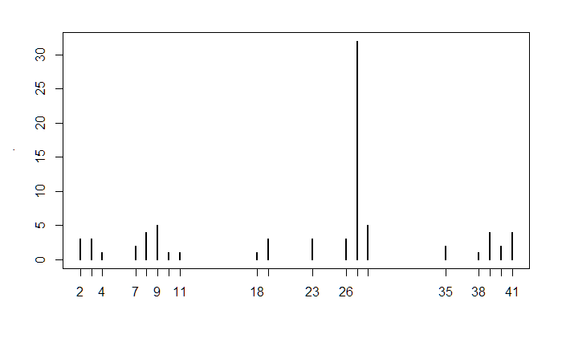

```r
EDD1_4 %>% filter(QC_type != "Blank") %>%
  {table(.$Project.Name, .$Sample.Date)} %>%
  as.data.frame() %>%
  filter(Freq > 0) %>% {table(.$Freq)} %>% plot()
```

```r
EDD1_4 %>% filter(QC_type != "Blank") %>%
  {table(.$Project.Name, .$Sample.Date)} %>%
  as.data.frame() %>%
  filter(Freq > 0) %>%
  {table(.$Var1)} %>% as.data.frame(.) %>% filter(Freq > 1) %>%
  arrange(desc(Freq))
```

| Var1 | Freq |
| --- | --- |
| C2019-00162 | 2 |

#### 7.15 CBI Sample-[meta]-data Corrections

1. As of 190621, found 1 project (see above) where more than 1 sample date per Project.Name
- Correcting this from 1/16/19 to 1/15/19 will also add an additional 4 records that now match field-sample data
- Sample.Date of 1/15/19 CONFIRMED from trip sheets

```r
EDD1_4 %<>% mutate(
  Sample.Date = case_when(
    project=="CBI" &
      Project.Name=="C2019-00162" ~ as.Date("2019-01-15"),
    !is.na(Sample.Date) ~ Sample.Date),
  Sample.Comment = case_when(
    project=="CBI" &
      Project.Name=="C2019-00162" ~ "Date corrected to 190115",
    !is.na(Sample.Comment) ~ Sample.Comment)
)
# EDD1_4 %>% filter(
#   project=="CBI" &
#       Project.Name=="C2019-00162"
# ) %>%
#   distinct(Sample.Date)
```

2. One mismatch in field data; changing Sample Date for Chem data to match
- Site :: 4958031
- SDate :: EDD (181024; initial) & Field (181025)
- Change EDD-date to 10/25

```r
EDD1_4 %<>% mutate(
  Sample.Comment = case_when(
    project=="CBI" &
      MLID=="4958031" &
      Sample.Date == "2018-10-24" &
      (is.na(Sample.Comment) | Sample.Comment != "") ~ "Date corrected to 181025",
    project=="CBI" &
      MLID=="4958031" &
      Sample.Date == "2018-10-24" &
      !is.na(Sample.Comment) ~ paste(Sample.Comment,
                                    "Date corrected to 181025",
                                    sep=";"),
    !is.na(Sample.Comment) ~ Sample.Comment),
  Sample.Date = case_when(
    project=="CBI" &
      MLID=="4958031" &
      Sample.Date == "2018-10-24" ~ as.Date("2018-10-25"),
    !is.na(Sample.Date) ~ Sample.Date)
)
## manual fix:
# EDD1_4 %<>% mutate(
#   Sample.Comment = case_when(
#     Project.Name == "C2018-06456" ~ "Date corrected to 181025",
#     !is.na(Sample.Comment) ~ Sample.Comment
#   )
# )
# EDD1_4 %>% filter(
#   project=="CBI" &
#     MLID=="4958031" &
#     Sample.Date == "2018-10-24") %>%
#   distinct(Sample.Date)
```

#### **Re-calculate Sample.Keys** [re-start here]

```r
EDD1_4 %<>% mutate(
  SKey1 = paste(.$MLID,
                as.numeric(trunc(.$Sample.Date) - as.Date("1899-12-30")),
                sep="."),
  SKey2 = paste(.$MLID,
                as.numeric(trunc(.$Sample.Date) - as.Date("1899-12-30")),
                .$Sample.Number,
                sep="."),
  SKey3 = paste(.$MLID,
                as.numeric(trunc(.$Sample.Date) - as.Date("1899-12-30")),
                .$Sample.Number,
                .$Sample.Type,
                sep="."),
  SKey4 = paste(.$MLID,
                as.numeric(trunc(.$Sample.Date) - as.Date("1899-12-30")),
                .$Sample.Type,
                sep="."),
  ACT_trunc = paste(.$Trip.ID,
                    .$MLID,
                    paste(sprintf("%.2d", lubridate::month(.$Sample.Date)),
                        sprintf("%.2d", lubridate::day(.$Sample.Date)),
                        sep=""),
                    .$Sample.Type,
                    sep="-"),
  ACT_00 = paste(.$project,
                 .$MLID,
                 paste(sprintf("%.2d", lubridate::month(.$Sample.Date)),
                       sprintf("%.2d", lubridate::day(.$Sample.Date)),
                       sep=""),
                 .$Sample.Type,
                 sep="-"),
  ACT_11 = paste(.$project,
                 .$MLID,
                 paste(sprintf("%.2d", lubridate::month(.$Sample.Date)),
                       sprintf("%.2d", lubridate::day(.$Sample.Date)),
                       sep=""),
                 sep="-")
)
```

- **Re-Run Field/Lab Matchups**
- **Keys** ::
  - SKey4
  - ACT_trunc (for completeness)

```r
fld_sk4 <- field_1 %>% distinct(SKey4)
fld_actrunc <- field_1 %>% distinct(ACT_trunc)
#
EDD1_4 %<>% mutate(
  field_sk4 = case_when(
    SKey4 %in% fld_sk4$SKey4 ~ "y",
    !is.na(field_sk4) ~ field_sk4,
    TRUE ~ as.character(NA)),
  field_actrunc = case_when(
    ACT_trunc %in% fld_actrunc$ACT_trunc ~ "y",
    !is.na(field_actrunc) ~ field_actrunc,
    TRUE ~ as.character(NA))
)
##
field_1 %<>% mutate(
  edd_sk4 = case_when(
    SKey4 %in% EDD1_4$SKey4 ~ "y",
    TRUE ~ as.character(NA))
)
```

- `match_STATUS` re-calc

```r
EDD1_4 %>% filter(project=="CBI") %>%
  {addmargins(table(.$field_sk4, .$match_STATUS, useNA="ifany", deparse.level = 2))}
```

```
           .$match_STATUS
.$field_sk4 Blank    ok REVIEW   Sum
       y        0 13757     23 13780
       <NA>  1541     0      0  1541
       Sum   1541 13757     23 15321
```

```r
#
field_1 %>% filter(project=="CBI") %>%
  {addmargins(table(.$edd_sk4, .$match_STATUS, useNA="ifany", deparse.level = 2))}
```

```
         .$match_STATUS
.$edd_sk4 IGNORE  ok Sum
     y         0 465 465
     <NA>      2  78  80
     Sum       2 543 545
```

```r
EDD1_4 %<>% mutate(
   match_STATUS = case_when(
    project == "CBI" & field_sk4 == "y" ~ "ok",
    project == "CBI" & is.na(field_sk4) & QC_type == "Blank" ~ "Blank",
    project == "CBI" & !is.na(match_STATUS) ~ match_STATUS,
    project == "CBI" & is.na(field_sk4) ~ "REVIEW",
    TRUE ~ as.character(NA)
))
##
field_1 %<>% mutate(
  match_STATUS = case_when(
    project=="CBI" & edd_sk4 == "y" ~ "ok",
    project=="CBI" & is.na(edd_sk4) & Ignore.3 == 11 ~ "ok", #for no access
    project=="CBI" & is.na(edd_sk4) &
      grepl("samples missing", Ignore.QC.Matchup.Notes,ignore.case = T) ~ "IGNORE",
    project=="CBI" & is.na(edd_sk4) ~ "REVIEW", #specific corrections preceeding
    project=="CBI" & !is.na(match_STATUS) ~ match_STATUS,
    TRUE ~ as.character(NA)
    )
)
```

```r
EDD1_4 %>% filter(project=="CBI") %>%
  {addmargins(table(.$field_sk4, .$match_STATUS, useNA="ifany", deparse.level = 2))}
```

```
           .$match_STATUS
.$field_sk4 Blank    ok   Sum
       y        0 13780 13780
       <NA>  1541     0  1541
       Sum   1541 13780 15321
```

```r
#
field_1 %>% filter(project=="CBI") %>%
  {addmargins(table(.$edd_sk4, .$match_STATUS, useNA="ifany", deparse.level = 2))}
```

```
         .$match_STATUS
.$edd_sk4 IGNORE  ok Sum
     y         0 465 465
     <NA>      2  78  80
     Sum       2 543 545
```

**The above two chunks are iterative**

- `field_1` looks okay for CBI
- Projects (in CBI) that still need REVIEW ::

```r
EDD1_4 %>% filter(match_STATUS == "REVIEW" & project=="CBI") %>% distinct(Project.Name, SKey4, Sample.Date, Sample.Time)
```

| Project.Name | SKey4 | Sample.Date | Sample.Time |
| --- | --- | --- | --- |

- *When the above DF-table is empty, skip next block and continue…*

[190621] :: in EDD1_4 that need review

1. C2019-00481 4955330.43509.4 2019-02-13 :: chem MLID should be 4955300
2. C2018-07199 4945120.43447.4 2018-12-13 :: chem MLID should be 4950120
3. C2018-06467 4959300.43396.4 2018-10-23 :: partial match, chem SDate should be 10/25/18

**Q**:: Why are there discrepancies b/w Field_data/Trip_sheets/Lab_sheets *vs* EDD_data ?

**Apply changes to `EDD1_4 from list above`**

```r
# build Sample.Comment first, then data-element
# C2019-00481   4955330.43509.4 2019-02-13 [MLID]
EDD1_4 %<>% mutate(
  Sample.Comment = case_when(
    project=="CBI" &
      Project.Name=="C2019-00481" &
      MLID == "4955330" &
      (is.na(Sample.Comment) | Sample.Comment == "") ~ "MLID corrected to 4955300",
    project=="CBI" &
      Project.Name=="C2019-00481" &
      MLID == "4955330" &
      !is.na(Sample.Comment) ~ paste(Sample.Comment, "MLID corrected to 4955300",
                                     sep=";"),
    !is.na(Sample.Comment) ~ Sample.Comment),
  MLID = case_when(
    project=="CBI" &
      Project.Name=="C2019-00481" &
      MLID == "4955330" ~ "4955300",
    !is.na(MLID) ~ MLID))
## C2018-07199  4945120.43447.4 2018-12-13 [MLID]
EDD1_4 %<>% mutate(
  Sample.Comment = case_when(
    project=="CBI" &
      Project.Name=="C2018-07199" &
      MLID == "4945120" &
      (is.na(Sample.Comment) | Sample.Comment == "") ~ "MLID corrected to 4950120",
    project=="CBI" &
      Project.Name=="C2018-07199" &
      MLID == "4945120" &
      !is.na(Sample.Comment) ~ paste(Sample.Comment, "MLID corrected to 4950120",
                                     sep=";"),
    !is.na(Sample.Comment) ~ Sample.Comment),
  MLID = case_when(
   project=="CBI" &
      Project.Name=="C2018-07199" &
      MLID == "4945120" ~ "4950120",
    !is.na(MLID) ~ MLID))
##  C2018-06467 4959300.43396.4 2018-10-23 [SDate]
EDD1_4 %<>% mutate(
  Sample.Comment = case_when(
    project=="CBI" &
      Project.Name=="C2018-06467" &
      Sample.Date == "2018-10-23" &
      (is.na(Sample.Comment) | Sample.Comment == "") ~ "SampDate corrected to 181023",
    project=="CBI" &
      Project.Name=="C2018-06467" &
      Sample.Date == "2018-10-23" &
      !is.na(Sample.Comment) ~ paste(Sample.Comment, "SampDate corrected to 181023",
                                     sep=";"),
    !is.na(Sample.Comment) ~ Sample.Comment),
  Sample.Date = case_when(
   project=="CBI" &
      Project.Name=="C2018-06467" &
      Sample.Date == "2018-10-23" ~ as.Date("2018-10-25"),
    !is.na(Sample.Date) ~ Sample.Date))
```

**Go back and re-run SKeys and Matchups**

**[190621]** :: CBI project tables look good.

#### 7.16 Summarize CBI matchups

- Comparing `field_sk4` [in EDD1_4] AND `edd_sk4` [in field_1] **VS** `match_STATUS`

```r
EDD1_4 %>% filter(project=="CBI") %>%
  {addmargins(table(.$field_sk4, .$match_STATUS, useNA="ifany", deparse.level = 2))} %>%
  htmlTable::htmlTable(., css.cell = rbind(rep("padding-left: 0.8em; padding-right: 0.8em;font-size: 0.75em;", times=ncol(.)+1), matrix("padding-left: 0.75em; padding-right: 0.75em; font-size: 0.75em;", ncol=ncol(.)+1, nrow=nrow(.))))
```

|  | .$match_STATUS Blank | .$match_STATUS ok |  | Sum |
| --- | --- | --- | --- | --- |
| .$field_sk4 |  |  |  |  |
| y | 0 | 13780 |  | 13780 |
| NA | 1541 | 0 |  | 1541 |
| Sum | 1541 | 13780 |  | 15321 |

```r
#
field_1 %>% filter(project=="CBI") %>%
  {addmargins(table(.$edd_sk4, .$match_STATUS, useNA="ifany", deparse.level = 2))} %>%
  htmlTable::htmlTable(., css.cell = rbind(rep("padding-left: 0.8em; padding-right: 0.8em;font-size: 0.75em;", times=ncol(.)+1), matrix("padding-left: 0.75em; padding-right: 0.75em; font-size: 0.75em;", ncol=ncol(.)+1, nrow=nrow(.))))
```

|  | .$match_STATUS IGNORE | .$match_STATUS ok |  | Sum |
| --- | --- | --- | --- | --- |
| .$edd_sk4 |  |  |  |  |
| y | 0 | 465 |  | 465 |
| NA | 2 | 78 |  | 80 |
| Sum | 2 | 543 |  | 545 |

- All **CBI** records seem to match.

#### 7.17 Annotate DF file for **CBI**

- See top table from 7.16 above
- Translate to `RECORD_status`

```r
EDD1_4 %<>% mutate(
  RECORD_STATUS = case_when(
    project=="CBI" & match_STATUS == "ok" ~ "CBI_2_import",
    project=="CBI" & is.na(field_sk4) & match_STATUS == "Blank" ~ "CBI_2_import",
    !is.na(RECORD_STATUS) ~ RECORD_STATUS,
    TRUE ~ as.character(NA)))
# EDD1_4 %>%
#   filter(project == "CBI" &
#            is.na(field_sk4) & match_STATUS == "Blank") %>% nrow()
```

```r
EDD1_4 %>% {addmargins(table(.$RECORD_STATUS, .$import_STATUS, useNA = "ifany", deparse.level = 2))}
```

```
               .$import_STATUS
.$RECORD_STATUS yes_0 yes_1 yes_x  <NA>   Sum
   CBI_2_import     0     0     0 15321 15321
   <NA>           914   814  1496  9546 12770
   Sum            914   814  1496 24867 28091
```

#### 7.18 Export DFs

```r
openxlsx::write.xlsx(list("EDD1_4" = EDD1_4, "field_1" = field_1), file=paste("EDD1_4_xx_",
                                        format(Sys.Date(), "%y%m%d"),
                                        ".xlsx", sep=""))
```

```
Note: zip::zip() is deprecated, please use zip::zipr() instead
```

```r
# save EDD1_4 file as RDS
saveRDS(EDD1_4, file=paste("EDD1_4_xx_",
                                        format(Sys.Date(), "%y%m%d"),
                                        ".rds", sep=""))
saveRDS(field_1, file=paste("field_1_xx_",
                                        format(Sys.Date(), "%y%m%d"),
                                        ".rds", sep=""))
```

> Moving on…

### Version Datafiles

```r
EDD1_5 <- EDD1_4
field_2 <- field_1
```

- A little DF cleanup

```r
EDD1_5 %<>% select(-SKey2, everything()) %>%
  select(project:Sample.Received.Date, Sample.Comment, Sample.Description, everything())
```

### 7.2 Utah Lake

**Chemistry // EDDs**

- Sample Date range (year and month)

```r
EDD1_5 %>% filter(project=="UTLK") %>%
  {addmargins(table(paste(lubridate::year(.$Sample.Date), lubridate::month(.$Sample.Date), sep="_"),
                    useNA="ifany", deparse.level = 2))}
```

```
paste(lubridate::year(.$Sample.Date), lubridate::month(.$Sample.Date),
2018_10 2018_11 2018_12  2019_1  2019_2     Sum
   1168    1008     601     503     550    3830
```

```r
EDD1_5 %>% filter(project=="UTLK") %>%
  {table(.$MLID_chek, useNA="ifany", deparse.level = 2)}
```

```
.$MLID_chek
  ok
3830
```

- **All UTLK MLIDs are okay (in MonLoc.file)**

```r
EDD1_5 %>% filter(project=="UTLK") %>%
  {table(.$import_STATUS, useNA="ifany", deparse.level = 2)}
```

```
.$import_STATUS
yes_0 yes_1 yes_x  <NA>
  728   814  1203  1085
```

```r
EDD1_5 %>% filter(project=="UTLK") %>%
  {addmargins(table(paste(lubridate::year(.$Sample.Date), lubridate::month(.$Sample.Date), sep="_"),
                    .$import_STATUS,
                    dnn=c("SDate_YrMon", "import_STATUS"),
                    useNA="ifany", deparse.level = 2))}
```

```
           import_STATUS
SDate_YrMon yes_0 yes_1 yes_x <NA>  Sum
    2018_10   720   448     0    0 1168
    2018_11     8   366   602   32 1008
    2018_12     0     0   601    0  601
    2019_1      0     0     0  503  503
    2019_2      0     0     0  550  550
    Sum       728   814  1203 1085 3830
```

- A few records from Nov-2018 and all from 2019 have not yet been imported…
- **`import_STATUS` is *NULL* records need further review**

```r
EDD1_5 %>% filter(project=="UTLK") %>%
  {table(.$field_sk4, useNA="ifany", deparse.level = 2)}
```

```
.$field_sk4
   y <NA>
 940 2890
```

- Many records with no field-match

```r
EDD1_5 %>% filter(project=="UTLK") %>%
  {addmargins(table(.$field_sk4, .$import_STATUS,
         useNA="ifany", deparse.level = 2))}
```

```
           .$import_STATUS
.$field_sk4 yes_0 yes_1 yes_x <NA>  Sum
       y        0     0     0  940  940
       <NA>   728   814  1203  145 2890
       Sum    728   814  1203 1085 3830
```

- Record w/ Field-match **are not already in AWQMS** :: 940 records
- **Some** records w/ No-Field-match are not in AWQMS and **Need to be Reviewed** :: 145 records

**ADD `import_STATUS == NA` to project filter**

```r
EDD1_5 %>% filter(project=="UTLK") %>%
  {addmargins(table(paste( .$import_STATUS,
                           .$field_sk4, sep="_"),
                    .$QC_type,
         useNA="ifany", deparse.level = 2))}
```

```
                                              .$QC_type
paste(.$import_STATUS, .$field_sk4, sep = "_") Blank Replicate <NA>  Sum
                                      NA_NA      113         0   32  145
                                      NA_y         0         0  940  940
                                      yes_0_NA   116         0  612  728
                                      yes_1_NA     0        72  742  814
                                      yes_x_NA   181         0 1022 1203
                                      Sum        410        72 3348 3830
```

```r
EDD1_5 %>% filter(project=="UTLK" & is.na(import_STATUS)) %>%
  {addmargins(table(.$field_sk4, .$QC_type,
         useNA="ifany", deparse.level = 2))}
```

```
           .$QC_type
.$field_sk4 Blank <NA>  Sum
       y        0  940  940
       <NA>   113   32  145
       Sum    113  972 1085
```

- No Replicate sites in data that are yet to be imported
- Recall that Blanks **Do Not require a field-match** (as there are no field data)

```r
EDD1_5 %>% filter(project=="UTLK" & is.na(import_STATUS) ) %>%
  {addmargins(table(.$field_sk4, .$QC_type,
         useNA="ifany", deparse.level = 2))}
```

```
           .$QC_type
.$field_sk4 Blank <NA>  Sum
       y        0  940  940
       <NA>   113   32  145
       Sum    113  972 1085
```

```r
EDD1_5 %>% filter(project=="UTLK" & is.na(import_STATUS) ) %>%
  distinct(SKey4, .keep_all = T) %>%
  {addmargins(table(.$field_sk4, .$QC_type,
         useNA="ifany", deparse.level = 2))}
```

```
           .$QC_type
.$field_sk4 Blank <NA> Sum
       y        0   29  29
       <NA>     7    1   8
       Sum      7   30  37
```

```r
EDD1_5 %>% filter(project=="UTLK" &
                    is.na(import_STATUS) &
                    is.na(QC_type) &
                    is.na(field_sk4)) %>%
  distinct(Project.Name, SKey4, Sample.Date)
```

| Project.Name | SKey4 | Sample.Date |
| --- | --- | --- |
| C2018-06911 | 4995310.43431.4 | 2018-11-27 |
| C2018-06912 | 4995310.43431.4 | 2018-11-27 |

**Field Data**

- Sample Date Range :: from 2019-01-15 to 2019-02-21
  - Appear to be missing late 2018 and march 2019 field data

```r
field_2 %>% filter(project=="UTLK") %>%
  {addmargins(table(
    paste(lubridate::year(.$Activity.Start.Date), lubridate::month(.$Activity.Start.Date), sep="_"),
    dnn=c("SDate_YrMon"),
    useNA="ifany", deparse.level = 2))}
```

```
SDate_YrMon
2019_1 2019_2    Sum
    14     15     29
```

**?? Where’d all the 2018 field data go???**

## Version Notebook

- Start notebook [03]

## 8.0 Method/Parameter Cleanup & Matchups

## 9.0 Record status REVIEW

## END

**Start work date ::** 190618  
**Last work date ::** 190624  
**Current review date ::** 190624

eof